```python
import numpy as np
from scipy.stats import norm, invgamma, gamma
import copy
import time
import warnings
import csv
import matplotlib.pyplot as plt
from statsmodels.graphics.tsaplots import plot_acf
```

```python
from geneology import particleGeneologyAll
```

# *Assignment 4*

Welcome to Assignment 4! In this assignment you are allowed to work *individually or in pairs*. It is worth 25 points in total.

### *Difference in this assignment*

You have two options: **either** you implement

1. PyClone, or
2. Particle Gibbs with Ancestral Sampling

**You are only allowed to do one of the above**. They are worth 25 points each. As usual, there is a 5 point minimum for passing this assignment (you need to pass all four assignments to be able to pass the course, see the grade chart on the Canvas course page for more details).

Submission details: Your submission should contain two pdf's.

1. A pdf version of your filled out colaboratory on Canvas. You can do this by pressing `cmd/ctrl+p` (you know the drill from there).
2. For Exercise 1, you need to hand in your hand-written solutions in a LaTeX pdf. We only accept solutions written in LaTeX, i.e. not Word or any other text editor. We recommend [Overleaf](https://overleaf.com), if you do not already have a favourite LaTeX editor (which is also [provided by KTH](https://intra.kth.se/en/it/programvara-o-system/programvara/installera/download/overleaf/overleaf-1.932755)).

# *1. PyClone - Dirichlet Process Mixture Model (DPMM)*

In this problem, you should apply a collapsed Gibbs sampler in order to cluster mutations based on a Dirichlet Process Mixture Model (DPMM). The probabilistic model can, following the original publication, be described by the graphical model in Figure 1(a), where H is a Dirichlet Process (DP). We will instead use the graphical model in Figure 1(b), which yields the same distribution when equipped with distributions as follows,

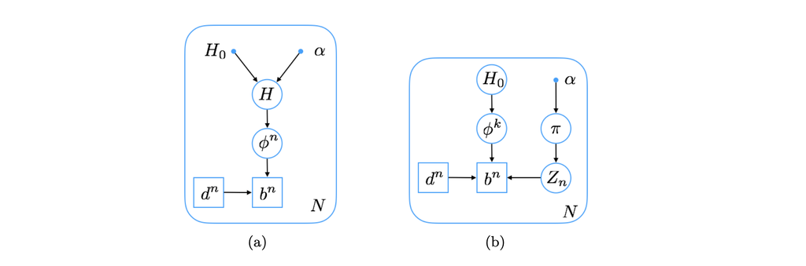

\begin{align} \pi &\sim GEM(\alpha) \\ z_n &\sim \pi \\ \phi^k &\sim H_0 = Beta (a_0,a_1) \\ d^n &\sim Poisson(d_0) \\ b^n &\sim Bin (d^n , \phi^{Z_n}) \end{align}

where GEM (stands for Griffiths, Engen, and McCloskey) denotes the stick-breaking process.

## 1.1 Generative Model

### 1.1.1 Generate Synthetic Data

Implement forward simulator to generate synthetic data that accepts hyperparameters and the number of data points as inputs.

```python
# generate synthetic data here
```

### 1.1.2 Describe the data

Report the followings regarding the data you generated:

1. hyperparameters employed,
2. number of clusters,
3. number of datapoints in each cluster (you can also visualize it by a histogram).

*Describe your data here*

## 1.2 Inference on DPMM

For the sake of simplicity, we will treat variables $d$ as observed in this section.

### 1.2.1 Collapsed Gibbs sampler

As exact analysis of DPMM is intractable, we use Gibbs sampling for inference. To implement a Gibbs sampler we need to derive the conditional distribution for the class assignments $z$. We mainly need the individual class assignment conditioned on the class assignments of all other objects and the data x, $p(z_n = k | z_{−n}, x)$, which can be expressed as, \begin{equation} p(z_n = k | z_{−n}, x) \propto p(z_n = k | z_{−n}) p(x_n | x_{-n} ,z_n = k, z_{-n}) \end{equation}

We will first focus on the first term $p(z_n = k | z_{−n})$.

Consider the finite mixture model, where K is fixed: \begin{equation} p(z_n = k | z_{−n}) = \int p(z_n = k | \pi) p(\pi | z_{−n}, \alpha) d\pi \end{equation} By construction the above equation corresponds to the posterior predictive for a multinomial distribution with a Dirichlet prior with parameter ($\alpha$ = ($\alpha$/K, . . . , $\alpha$/K)), which can be solved analytically \begin{equation} p(z_n = k | z_{−n}) = \frac {N_{-n,k}+ \frac{\alpha}{K}}{N -1 + \alpha} \end{equation} where $N_{−n,k}$ is the number of objects assigned to $k$th class excluding the $n$th object.

For infinite case (equivalent to the Chinese restaurant process), $K \rightarrow \infty $, \begin{equation} p(z_n = k | z_{−n}) = \bigg\{ \begin{array}{lr} \frac {N_{-n,k}}{N -1 + \alpha} \;\;\; \text{,if k has been seen before $N_{-n,k} > 0 $} \\ \frac {\alpha}{N -1 + \alpha} \;\;\; \text{,if k is a new cluster} \end{array} \end{equation}

Now, consider the second term $p(x_n | x_{-n} ,z_n = k, z_{-n})$.

If $k \in 1, ... , K$, then it is the posterior predictive distribution for cluster $k$ evaluated at point $x_n$,

\begin{align} p(x_n | x_{-n} ,z_n = k, z_{-n}) = BetaBinomial(x_n | d^n,a_0^k,a_1^k) \end{align}

where $a_0^k$ and $a_1^k$ are the posterior hyperparameters for the $k$th cluster,

\begin{align} a_0^k &= a_0 + \sum_{i=1}^N b^i \mathbf{1}[z_i = k] \\ a_1^k &= a_1 + \sum_{i=1}^N (d^i - b^i) \mathbf{1}[z_i = k] \end{align}

If $k$ is a new cluster, then it is the prior predictive distribution evaluated at point $x_n$,

\begin{align} p(x_n | x_{-n} ,z_n = k, z_{-n}) = BetaBinomial(x_n | d^n,a_0,a_1) \end{align}

where $a_0$ and $a_1$ are the prior hyperparameters.

Implement collapsed Gibbs sampler for this DPMM. Test it on synthetic data with the following values of the hyperparameters: $\alpha = 1$, $a_0 = a_1 = 1$, and $d_0 = 1000$. Provide a figure depicting accuracy of clustering.

Make sure to do the calculations in the logarithmic scale for numeric stability.

(Hint: You can write BetaBinomial distribution in terms of gamma functions. Check scipy.special.loggamma function.)

```python
# Implement collapsed Gibbs sampler here
```

### 1.2.2 Effect of DP parameters

#### 1.2.2.1 The parameter $\alpha$

The number of clusters can be controlled via the parameter $\alpha$. Re-do collapsed Gibbs sampling for two different values of $\alpha$ and comment on the results. How does the performance change with increasing\decreasing number of clusters?

```python
# try collapsed Gibbs sampler for different alpha's
```

#### 1.2.2.2 Number of data points

How is the number of data points affecting the performance? Experiment with two different number of data points.

```python
# try collapsed Gibbs sampler for different number of data points
```

# *2. Particle Gibbs with Ancestral Sampling*

**Relevant resources:**

- Andrieu, Christophe, Arnaud Doucet, and Roman Holenstein. "[Particle markov chain monte carlo methods.](https://www.stats.ox.ac.uk/~doucet/andrieu_doucet_holenstein_PMCMC.pdf)" Journal of the Royal Statistical Society: Series B (Statistical Methodology) 72.3 (2010): 269-342.
- Lindsten, Fredrik, Michael I. Jordan, and Thomas B. Schon. "[Particle Gibbs with ancestor sampling.](https://www.jmlr.org/papers/volume15/lindsten14a/lindsten14a.pdf)" Journal of Machine Learning Research 15 (2014): 2145-2184.
- Uppsala university's SMC course (see our lecture slides for refences).
- Our lecture slides available on Canvas.

This is a follow-up task from Assigment 3. If you implemented the BPF, you will be able to reuse code from the last assignment (**if you did not implement the BPF before, you get the chance to implement it here instead**). There, you were asked to find the parameters, $\theta$, that most likely generated the observations, $y_{1:T}$ by evaluating $p(y_{1:T}|\theta)$ for different choices of $\theta$ (recall the grid search).

Here you will learn a more elegant method for inferring probable parameters: via a combination of particle filtering and MCMC, hence termed PMCMC. This approach was first proposed by Andrieu et al. (in the first item above). You are asked to first implement the particle Gibbs (PG) method, which we discussed in the lectures, and then augment it using "ancestor sampling" (proposed in the second item). Throughout the assignment we will continue to work with the stochastic volatility (SV) model from the previous assignment, included here for completeness:

### **SV Model**

$$\begin{equation*} x_1 \sim \mathcal{N}(0, \frac{\sigma^2}{1 - \alpha ^2}), \end{equation*}$$$$\begin{equation*} x_n \sim \mathcal{N}(\alpha x_{n-1}, \sigma^2), \end{equation*}$$$$\begin{equation*} y_n \sim \mathcal{N}(0, \beta^2\exp(x_{n})), \end{equation*}$$

for $n=1,...,T$. We will assume that the parameters $\beta$ and $\sigma^2$ are unknown, while we assume that $\alpha=0.91$.

## **Conjugate priors**

We place inverse Gamma priors on the variance parameters:

\begin{align} \sigma^2 & \sim \mathcal{IG}(a=0.01,b=0.01), \\ \beta^2 & \sim \mathcal{IG}(a=0.01,b=0.01), \end{align}

where the the inverse Gamma pdf with parameters $(a,b)$ is given by \begin{equation} \mathcal{IG}(x|a,b)=\frac{b^a}{\Gamma(a)} x^{-a-1} \exp\left(-\frac{b}{x}\right) \end{equation} and $\Gamma$ is the Gamma function.

These priors are conjugate to the corresponding SV model pdf's and yield the following posteriors \begin{equation} p(\sigma^2|x_{1:T}, \alpha) = \mathcal{IG}\left(\sigma^2|a + \frac{T}{2}, b + \frac{x_1^2(1 - \alpha^2)}{2} + \frac{1}{2}\sum^{T}_{n=2} (x_n - \alpha x_{n-1})^2\right), \end{equation}

\begin{equation} p(\beta|x_{1:T}, y_{1:T}) = \mathcal{IG}\left(\beta|a + \frac{T}{2}, b + \frac{1}{2} \sum^T_{n=1}e^{-x_n}y_n^2\right) \end{equation}

## **2.1 Implement the Particle Gibbs**

Implement a particle Gibbs sampler to compute the posterior distribution $p(\sigma^2,\beta^2|\alpha,y_{1:T})$. To do so, alternately sample from

- $p(\sigma^2|\alpha,x_{1:T})$,
- $p(\beta|x_{1:T},y_{1:T})$,
- $p(x_{1:T}|\theta,y_{1:T})$ using conditional SMC.

To recall what a conditional SMC is, have a look at the SMC lecture slides (lecture 2 specifically), or the other resources.

Use a bootstrap particle filter (BPF) and resample at every iteration. Use the multinomial resampling scheme. **Hint:** read through what you need to report as stated below, before you start coding.

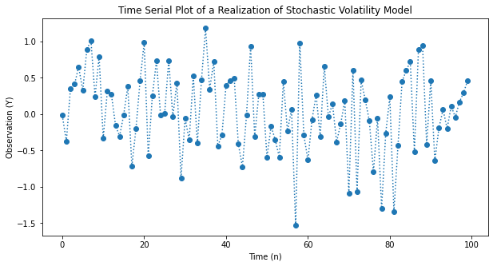

```python
# load observations.npy from the SMC module on Canvas and do the grid search below
sv_obs = np.load("observations.npy")

plt.rc("figure", figsize=(10,5))
plt.plot(sv_obs, ':o')
plt.xlabel("Time (n)")
plt.ylabel("Observation (Y)")
plt.title("Time Serial Plot of a Realization of Stochastic Volatility Model")
plt.show()
```

```python
def LL_BPF(data, theta, K, seed):
    """data is an array of N observations
       theta is a dictionary of parameters and their values
       K is the number of particles"""

    np.random.seed(seed)
    cum_LL_n = []
    beta_sq = theta[0]
    alpha = theta[1]
    sigma_sq = theta[2]

    xgen_n = np.random.normal(loc=0, scale=(np.sqrt(sigma_sq/(1-alpha**2))), size=K) #because q(x_1) = p(x_1)
    w_n = np.repeat(1/K, K)
    cum_LL_n = np.append(cum_LL_n, np.log(norm.pdf(data[0], loc=0, scale=(np.sqrt((beta_sq)*np.exp(xgen_n)))).mean()+1e-4))

    for n in range(1, data.size):
        u = np.random.uniform(0, 1, size=K)
        prev_xgen_n = copy.deepcopy(xgen_n)
        cum_w_prev_n = np.array([w_n[:k].sum() for k in range(1,K+1)])
        a_n = [next(x[0] for x in enumerate(cum_w_prev_n) if x[1] > u[k]) for k in range(K)]
        xgen_n = np.random.normal(loc=(alpha*prev_xgen_n[a_n]), scale=(np.sqrt(sigma_sq)))
        cum_LL_n = np.append(cum_LL_n, cum_LL_n[n-1] + np.log(norm.pdf(data[n], loc=0, scale=(np.sqrt((beta_sq)*np.exp(xgen_n)))).mean()+1e-4))

    return(cum_LL_n)
```

```python
t0 = time.time()

# here alpha is fixed at .91
theta ={"beta_sq":np.linspace(.05, 1, 20), "alpha":np.array([.91]), "sigma_sq":np.linspace(.05, 1, 20)}
K = 100
seeds = np.random.choice(np.arange(1,1000), size=10, replace=False)

Results = {}

for seed in seeds:
    LL = {}
    params = {}
    i = 0
    for b2 in theta["beta_sq"]:
        for a in theta["alpha"]:
            for s2 in theta["sigma_sq"]:
                LL[i] = LL_BPF(sv_obs, (b2,a,s2), K, seed)
                params[i] = np.array([b2, a, s2])
                i += 1

    Results[seed] = LL

t1 = time.time()
total_time = t1 - t0
print('total time is', total_time//3600, 'hour', (total_time%3600)//60, 'minute', (total_time%3600)%60, 'seconds')
```

```
total time is 0.0 hour 7.0 minute 36.944265604019165 seconds
```

```python
s = 0
Report = {}
for seed,LL in Results.items():
    full_data_LL = np.empty(0)
    for _,values2 in Results[seed].items():
        full_data_LL = np.append(full_data_LL, values2[-1])

    Report[s] = (seed, full_data_LL.max(), np.where(full_data_LL == full_data_LL.max())[0][0])
    print("Seed " + str(Report[s][0]) +": The maximum log-likelihood of BPF with " + str(K) + " particles is " + str(round(Report[s][1],4)) + " and is achieved with [\u03B2\N{SUPERSCRIPT TWO}, \u03B1, \u03C3\N{SUPERSCRIPT TWO}] = " + str(params[Report[s][2]]))
    s += 1
```

```
Seed 940: The maximum log-likelihood of BPF with 100 particles is -85.2601 and is achieved with [β², α, σ²] = [0.3  0.91 0.05]
Seed 744: The maximum log-likelihood of BPF with 100 particles is -84.7972 and is achieved with [β², α, σ²] = [0.3  0.91 0.05]
Seed 870: The maximum log-likelihood of BPF with 100 particles is -83.8715 and is achieved with [β², α, σ²] = [0.3  0.91 0.05]
Seed 272: The maximum log-likelihood of BPF with 100 particles is -84.3284 and is achieved with [β², α, σ²] = [0.3  0.91 0.05]
Seed 987: The maximum log-likelihood of BPF with 100 particles is -85.1354 and is achieved with [β², α, σ²] = [0.3  0.91 0.05]
Seed 588: The maximum log-likelihood of BPF with 100 particles is -84.8023 and is achieved with [β², α, σ²] = [0.3  0.91 0.05]
Seed 514: The maximum log-likelihood of BPF with 100 particles is -83.9351 and is achieved with [β², α, σ²] = [0.3  0.91 0.05]
Seed 324: The maximum log-likelihood of BPF with 100 particles is -85.0844 and is achieved with [β², α, σ²] = [0.3  0.91 0.05]
Seed 808: The maximum log-likelihood of BPF with 100 particles is -84.6718 and is achieved with [β², α, σ²] = [0.3  0.91 0.05]
Seed 337: The maximum log-likelihood of BPF with 100 particles is -84.4002 and is achieved with [β², α, σ²] = [0.3  0.91 0.05]
```

```python
beta_sq = np.array([params[Report[s][2]][0] for s in range(seeds.size)]).mean()
alpha = np.array([params[Report[s][2]][1] for s in range(seeds.size)]).mean()
sigma_sq = np.array([params[Report[s][2]][2] for s in range(seeds.size)]).mean()
print('Expected parameters are \u03B8 = (' + str(round(beta_sq,2)) + ', ' + str(round(alpha,2)) + ', ' + str(round(sigma_sq,4)) + ')')
```

```
Expected parameters are θ = (0.3, 0.91, 0.05)
```

### The Particle Gibbs Implementation

##### *Notes:*

*These are the things that I did slightly differently from the instructions:*  
*- I reported $\beta^2$ here instead of $\beta$* ;  
*- I decided to restrict the sampled parameter values, for both $\beta^2$ and $\sigma^2$ to a lower-bound of $10^{-4}$ for the sake of avoiding numerical problems (extremely small values will produce near-zero pdf values which then lead to the undesired divisions by zero)* ;  
*- For the same reason as above, I also imposed an upper-bound of $10^3$ for both parameters* ;  
*- I used a gamma distribution sampler with the inverse parameters of 1/a and 1/b, instead of straight out using the inverse-gamma sampler (scipy.stats' invgamma) because the former is -again- more numerically stable. When I used the inverse-gamma sampler with the parameters a and b, it often led to an error message of 'Domain Error' and the sampling completely broke down* ;  
*- Finally, I just took the particle with maximum weight to resample the reference's (particle K's) ancestor in the PGAS implementation, instead of trying to roll out a dice and get a number proportional to the weights of the particles; but choosing the particle with the maximum weight is still, technically speaking, taking a sample in proportion to the weights of the particle (because the one with the max weight is supposed to be chosen the most often, on average)*

```python
def generate_sv_latent_sequence(data, theta):
    beta = theta[0]
    alpha = theta[1]
    sigma_sq = theta[2]
    y_n = data
    N = data.size

    xgen_n = [np.random.normal(loc=0, scale=(np.sqrt(sigma_sq/(1-alpha**2))))]
    xgen_n.extend([np.random.normal(loc=(alpha*xgen_n[-1]), scale=np.sqrt(sigma_sq)) for n in range(1,N)])

    return(np.array(xgen_n))
```

```python
def cond_SMC_kernel(data, x_ref, K, theta):
    """ *** BPF with multinomial resampling ***
       data is an array of N observations
       K is the number of particles
       theta is a dictionary of parameters and their values"""

    beta_sq = theta[0]
    alpha = theta[1]
    sigma_sq = theta[2]
    y_n = data
    N = data.size

    a_n = {}
    xgen_n = {}
    w_n = {}

    a_n[0] = np.arange(K)
    xgen_n[0] = np.append(np.random.normal(loc=0, scale=(np.sqrt(sigma_sq/(1-alpha**2))), size=(K-1)), x_ref[0])  #because q(x_1) = p(x_1)
    w_n[0] = np.repeat(1/K, K)

    for n in range(1,N):
        u = np.random.uniform(0, 1, size=(K-1))
        cum_w_prev_n = np.append(np.array([w_n[n-1][:k].sum() for k in range(1,K)]), 1)
        a_n[n] = np.append(np.array([next(x[0] for x in enumerate(cum_w_prev_n) if x[1] > u[k]) for k in range(K-1)]), K-1)
        xgen_n[n] = np.append(np.random.normal(loc=(alpha*xgen_n[n-1][a_n[n][:-1]]), scale=np.sqrt(sigma_sq)), x_ref[n])
        w_n[n] = norm.pdf(y_n[n], loc=0, scale=np.sqrt((beta_sq)*np.exp(xgen_n[n])))
        if all(w_n[n] < 1e-4):
            w_n[n] += 1e-4
        w_n[n] /= w_n[n].sum()

    return(w_n, xgen_n, a_n)
```

```python
def draw_from_SMC_mode(w_n, xgen_n, a_n, dead_tol):

    N = len(w_n)
    map_idx = np.random.randint(N-1)
    #map_idx = w_n[N-1].argmax()
    w_map = np.array([w_n[n][map_idx] for n in range(N)])

    w_anc = {}
    xref = np.empty(0)
    if any(w_map < dead_tol):      #check if the path is dead somewhere
        d = 0
        dead_pos = np.where(w_map < dead_tol)[0][-1]
        a_dead = np.array([a_n[dead_pos][map_idx]])
        w_anc[0] = np.array([w_n[n][a_dead] for n in range(dead_pos)])
        while any(w_anc[d] < dead_tol):
            d += 1
            dead_pos = np.append(dead_pos, np.array([np.where(w_anc[d-1] < dead_tol)[0][-1]]))
            a_dead = np.append(a_dead, a_n[dead_pos[d]][a_dead[d-1]])
            w_anc[d] = np.array([w_n[n][a_dead[d]] for n in range(dead_pos[d])])

        if not isinstance(dead_pos, np.ndarray):
            dead_pos = np.array([dead_pos])

        event_pos = np.concatenate(([N], dead_pos, [0]))
        a_hist = np.append(map_idx, a_dead)
        for i in range(event_pos.size-1):
            for n in range(event_pos[i]-1, event_pos[i+1]-1, -1):
                xref = np.append(xgen_n[n][a_hist[i]], xref)

    else:
        for n in range(N):
            xref = np.append(xref, xgen_n[n][map_idx])

    return(xref)
```

```python
def PG_kernel(data, sampled_x_ref, current_alpha, prior_hyperparams):

    a = prior_hyperparams[0]
    b = prior_hyperparams[1]
    y_n = data
    N = y_n.size

    posterior_a = a + N/2
    posterior_b_ssq = b + ((sampled_x_ref[0]**2)*(1-current_alpha**2))/2 + ((sampled_x_ref[1:N] - current_alpha*sampled_x_ref[0:N-1])**2).sum()/2
    posterior_b_bsq = b + np.dot(np.exp(-sampled_x_ref),(y_n**2))/2

    beta_sq, sigma_sq = gamma.rvs(a=posterior_a, scale=(1/posterior_b_bsq, 1/posterior_b_ssq))
    #beta, sigma_sq = np.random.gamma(posterior_a, scale=(1/posterior_b_bta, 1/posterior_b_ssq))

    flag_mini_bsq = 0
    flag_deka_bsq = 0
    flag_mini_ssq = 0
    flag_deka_ssq = 0
    if beta_sq < 1e-4:
        flag_mini_bsq += 1
        beta_sq = 1e-4
    if beta_sq > 1e3:
        flag_deka_bsq += 1
        beta_sq = 1e3
    if sigma_sq < 1e-4:
        flag_mini_ssq += 1
        sigma_sq = 1e-4
    if sigma_sq > 1e3:
        flag_deka_ssq += 1
        sigma_sq = 1e3

    flags = [flag_mini_bsq, flag_deka_bsq, flag_mini_ssq, flag_deka_ssq]

    return(beta_sq, sigma_sq, flags)
```

```python
def run_particle_gibbs_chain(nr_iter, data, theta_init, K, xref_init):

    alpha = theta_init[1]
    theta = {0: theta_init}
    x_ref = {0: xref_init}
    a_history = {}
    xgen_history = {}
    w_history = {}
    i = 0; j = 0; k = 0; l = 0
    for iter in range(1, nr_iter):
        w_n, xgen_n, a_n = cond_SMC_kernel(data, x_ref[iter-1], K, theta[iter-1])
        xref = draw_from_SMC_mode(w_n, xgen_n, a_n, 1e-4)
        beta_sq, sigma_sq, flags,  = PG_kernel(data, xref, alpha, (.01, .01))

        x_ref[iter] = xref
        theta[iter] = [beta_sq, theta_init[1], sigma_sq]
        a_history[iter] = a_n
        xgen_history[iter] = xgen_n
        w_history[iter] = w_n
        i += flags[0]
        j += flags[1]
        k += flags[2]
        l += flags[3]

    print("Cases of diminutive beta_sq occurred in " + str(i) + " out of " + str(nr_iter) + " iterations")
    print("Cases of excessive beta_sq occurred in " + str(j) + " out of " + str(nr_iter) + " iterations")
    print("Cases of diminutive sigma_sq occurred in " + str(k) + " out of " + str(nr_iter) + " iterations")
    print("Cases of excessive sigma_sq occurred in " + str(l) + " out of " + str(nr_iter) + " iterations")

    return(x_ref, theta, a_history, xgen_history, w_history)
```

```python
np.random.seed(173710)

nr_iter = 25000
nr_chain = 4
K = 100  #nr. of particles to generate

theta0 = {0:[.4, .91, .4], 1:[.01, .91, 1], 2:[.7, .91, .7], 3:[1, .91, .01]}
x_ref0 = {}
for ch in range(nr_chain):
    x_ref0[ch] = generate_sv_latent_sequence(sv_obs, theta0[0])

all_xref = {}
all_theta = {}
all_ahistory = {}
all_xgenhistory = {}
all_whistory = {}

t0 = time.time()

for chain in range(nr_chain):
    x_ref, theta, a_history, xgen_history, w_history = run_particle_gibbs_chain(nr_iter, sv_obs, theta0[chain], K, x_ref0[chain])

    all_xref[chain] = x_ref
    all_theta[chain] = theta
    all_ahistory[chain] = a_history
    all_xgenhistory[chain] = xgen_history
    all_whistory[chain] = w_history

t1 = time.time()
total_time = t1 - t0
warnings.filterwarnings(action='once')
print('total time is', total_time//3600, 'hour', (total_time%3600)//60, 'minute', (total_time%3600)%60, 'seconds')
```

```
Cases of diminutive beta_sq occurred in 0 out of 25000 iterations
Cases of excessive beta_sq occurred in 0 out of 25000 iterations
Cases of diminutive sigma_sq occurred in 0 out of 25000 iterations
Cases of excessive sigma_sq occurred in 0 out of 25000 iterations
Cases of diminutive beta_sq occurred in 0 out of 25000 iterations
Cases of excessive beta_sq occurred in 0 out of 25000 iterations
Cases of diminutive sigma_sq occurred in 0 out of 25000 iterations
Cases of excessive sigma_sq occurred in 0 out of 25000 iterations
Cases of diminutive beta_sq occurred in 0 out of 25000 iterations
Cases of excessive beta_sq occurred in 0 out of 25000 iterations
Cases of diminutive sigma_sq occurred in 0 out of 25000 iterations
Cases of excessive sigma_sq occurred in 0 out of 25000 iterations
Cases of diminutive beta_sq occurred in 0 out of 25000 iterations
Cases of excessive beta_sq occurred in 0 out of 25000 iterations
Cases of diminutive sigma_sq occurred in 0 out of 25000 iterations
Cases of excessive sigma_sq occurred in 0 out of 25000 iterations
total time is 3.0 hour 3.0 minute 16.05848455429077 seconds
```

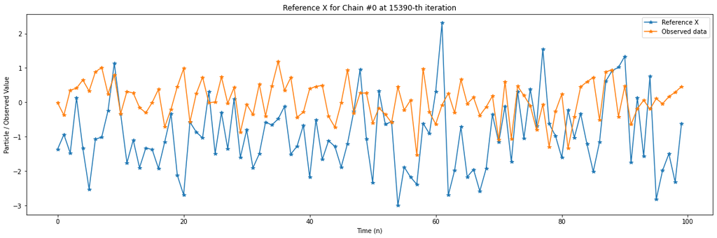

```python
i = 15390
chain = 0
plt.rc("figure", figsize=(20,6))
plt.plot(all_xref[chain][i], '-*')
plt.plot(sv_obs, '-*')
plt.legend(["Reference X", "Observed data"])
plt.xlabel("Time (n)")
plt.ylabel("Particle / Observed Value")
plt.title("Reference X for Chain #" + str(chain) + " at " + str(i) + "-th iteration")
plt.show()
```

## **Report the distributions $p(\sigma^2|\alpha,x_{1:T})$ and $p(\beta|x_{1:T},y_{1:T})$**

Use a trace plot to show that the PG has converged, and histograms to visualize the two distributions. Remember to discard the burn-in samples. If you did Assignment 3, how do these distributions correspond to your findings from the grid search? (You will not get point deduction if you have not done the grid search in assignment 3!)

## **Report the approximate marginal likelihood**

From the lecture slides, we know how to compute the following marginal likelihood

\begin{equation} p(y_{1:T}|\theta) = \int_{x_{1:T}} p(y_{1:T}|x_{1:T}, \theta) p(x_{1:T}|\theta) dx_{1:T} \approx \prod_{i=1}^T \sum_k\frac{1}{K} p(y_i|x_i^k, \theta). \end{equation}

Use the PG sampler to compute the marginal likelihood, averaged over your MCMC iterations.

**Motivate why this is an approximation of the marginal likelhood, $p(y_{1:T})$. How is $p(y_{1:T})$ different from $p(y_{1:T}|\theta)$?**

*Answer*

*Taking the average of marginal likelihood per parameter, $p(y_{1:T}|\theta)$, over all the sampled parameter values is equivalent to taking $\sum_\theta p(y_{1:T}|\theta)p(\theta) = p(y_{1:T})$. It's because the relative frequency of the parameter values in the sample itself (if they are correctly sampled) approximates $p(\theta)$*

### Sampled Parameter Distributions & Marginal Likelihood Computation

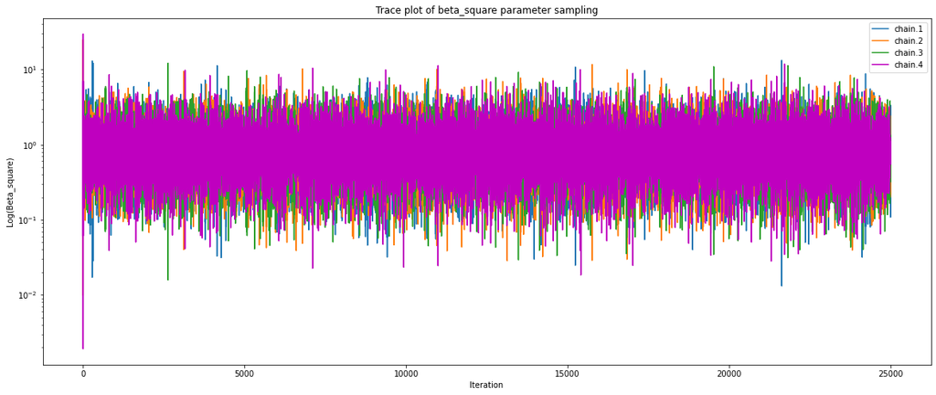

```python
# plot of chains: beta_sq
plt.rc("figure", figsize=(20,8))
plt.yscale("log")
plt.plot([all_theta[0][iter][0] for iter in range(nr_iter)], '-')
plt.plot([all_theta[1][iter][0] for iter in range(nr_iter)], '-')
plt.plot([all_theta[2][iter][0] for iter in range(nr_iter)], '-')
plt.plot([all_theta[3][iter][0] for iter in range(nr_iter)], '-m')
plt.legend(["chain.1","chain.2","chain.3","chain.4"])
plt.xlabel("Iteration")
plt.ylabel("Log(Beta_square)")
plt.title("Trace plot of beta_square parameter sampling")
plt.show()
```

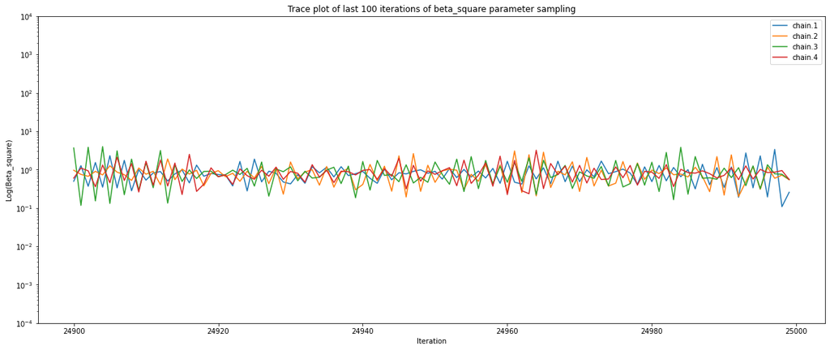

```python
# Convergence diagnostic: beta_sq, last i iterations
i = 100
plt.rc("figure", figsize=(20,8))
plt.yscale("log")
plt.plot(np.arange(nr_iter-i, nr_iter), [all_theta[0][iter][0] for iter in range(nr_iter-i, nr_iter)], '-')
plt.plot(np.arange(nr_iter-i, nr_iter), [all_theta[1][iter][0] for iter in range(nr_iter-i, nr_iter)], '-')
plt.plot(np.arange(nr_iter-i, nr_iter), [all_theta[2][iter][0] for iter in range(nr_iter-i, nr_iter)], '-')
plt.plot(np.arange(nr_iter-i, nr_iter), [all_theta[3][iter][0] for iter in range(nr_iter-i, nr_iter)], '-')
plt.legend(["chain.1","chain.2","chain.3","chain.4"])
plt.xlabel("Iteration")
plt.ylabel("Log(Beta_square)")
plt.ylim(10**-4, 10**4)
plt.title("Trace plot of last " + str(i) + " iterations of beta_square parameter sampling")
plt.show()
```

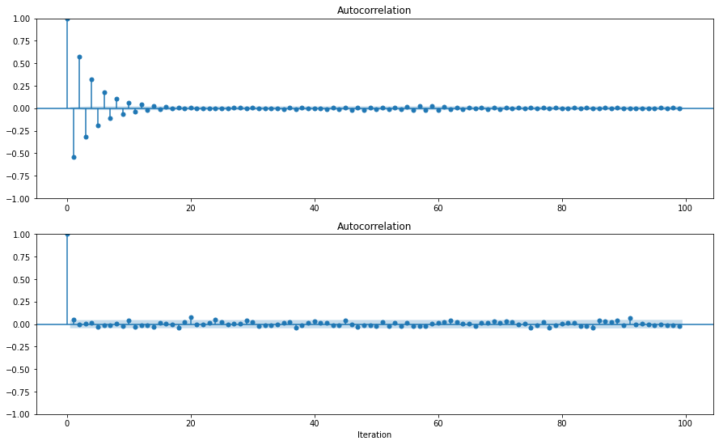

```python
# Diagnostic: ACF of beta_sq
which_chain = 0
burn_in = .25
thinning = .1

plt.rc("figure", figsize=(15,9))
fig, ax = plt.subplots(2)
plot_acf([all_theta[which_chain][iter][0] for iter in range(nr_iter)], lags=99, ax=ax[0])
plot_acf([all_theta[which_chain][iter][0] for iter in range(int(nr_iter*burn_in), nr_iter)][0::round(1/thinning)], lags=99, ax=ax[1])
ax[1].set_xlabel("Iteration")
plt.show()
```

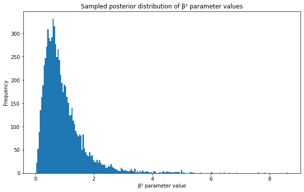

```
331.0
0.5845390669482078 0.6276265856138143
```

```python
# histogram of beta_sq
burn_in = .25
thinning = .1
all_bsq = []
for c in range(nr_chain):
    all_bsq.extend([all_theta[c][iter][0] for iter in range(int(nr_iter*burn_in), nr_iter)])
sampled_bsq = np.array(all_bsq[0::round(1/thinning)])
plt.rc("figure", figsize=(10,6))
n, bins, patches = plt.hist(sampled_bsq[(sampled_bsq > 1e-4) & (sampled_bsq < 1000)], bins=200) #exclude too big values, for better display
plt.ylabel("Frequency")
plt.xlabel("\u03B2\N{SUPERSCRIPT TWO} parameter value")
plt.title("Sampled posterior distribution of \u03B2\N{SUPERSCRIPT TWO} parameter values")
plt.show()

print(n.max())
print(bins[n.argmax()], bins[n.argmax()+1])
```

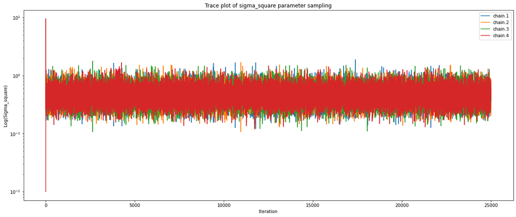

```python
# plot of chains: sigma_sq
plt.rc("figure", figsize=(20,8))
plt.yscale("log")
plt.plot([all_theta[0][iter][2] for iter in range(nr_iter)], '-')
plt.plot([all_theta[1][iter][2] for iter in range(nr_iter)], '-')
plt.plot([all_theta[2][iter][2] for iter in range(nr_iter)], '-')
plt.plot([all_theta[3][iter][2] for iter in range(nr_iter)], '-')
plt.legend(["chain.1","chain.2","chain.3","chain.4"])
plt.xlabel("Iteration")
plt.ylabel("Log(Sigma_square)")
plt.title("Trace plot of sigma_square parameter sampling")
plt.show()
```

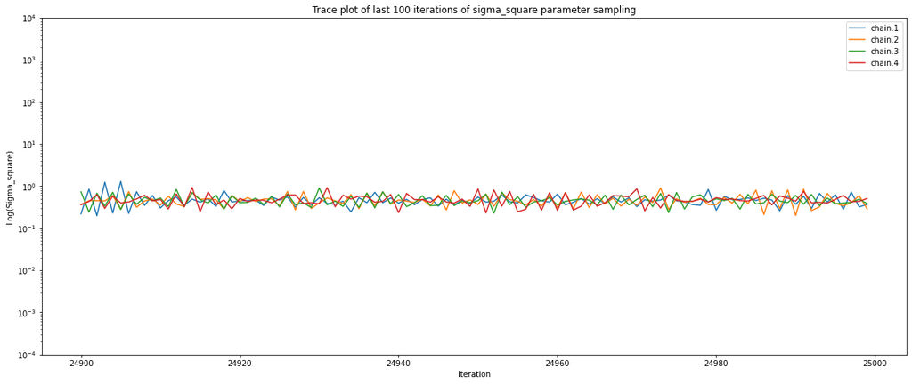

```python
# Convergence diagnostic: sigma_sq, last i iterations
i = 100
plt.rc("figure", figsize=(20,8))
plt.yscale("log")
plt.plot(np.arange(nr_iter-i, nr_iter), [all_theta[0][iter][2] for iter in range(nr_iter-i, nr_iter)], '-')
plt.plot(np.arange(nr_iter-i, nr_iter), [all_theta[1][iter][2] for iter in range(nr_iter-i, nr_iter)], '-')
plt.plot(np.arange(nr_iter-i, nr_iter), [all_theta[2][iter][2] for iter in range(nr_iter-i, nr_iter)], '-')
plt.plot(np.arange(nr_iter-i, nr_iter), [all_theta[3][iter][2] for iter in range(nr_iter-i, nr_iter)], '-')
plt.legend(["chain.1","chain.2","chain.3","chain.4"])
plt.xlabel("Iteration")
plt.ylabel("Log(Sigma_square)")
plt.ylim(10**-4, 10**4)
plt.title("Trace plot of last " + str(i) + " iterations of sigma_square parameter sampling")
plt.show()
```

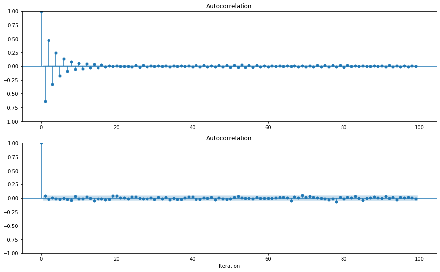

```python
# Diagnostic: ACF of sigma_sq
which_chain = 0
burn_in = .25
thinning = .1

plt.rc("figure", figsize=(15,9))
fig, ax = plt.subplots(2)
plot_acf([all_theta[which_chain][iter][2] for iter in range(nr_iter)], lags=99, ax=ax[0])
plot_acf([all_theta[which_chain][iter][2] for iter in range(int(nr_iter*burn_in), nr_iter)][0::round(1/thinning)], lags=99, ax=ax[1])
ax[1].set_xlabel("Iteration")
plt.show()
```

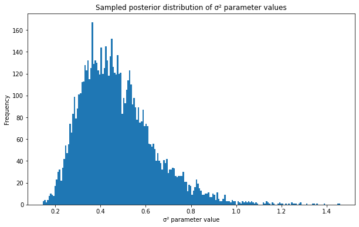

```
167.0
0.36102254668057543 0.3675976500154596
```

```python
# histogram of sigma_sq
burn_in = .25
thinning = .1
all_ssq = []
for c in range(nr_chain):
    all_ssq.extend([all_theta[c][iter][2] for iter in range(int(nr_iter*burn_in), nr_iter)])
sampled_ssq = np.array(all_ssq[0::round(1/thinning)])
plt.rc("figure", figsize=(10,6))
n, bins, patches = plt.hist(sampled_ssq[(sampled_ssq > 1e-4) & (sampled_ssq < 1000)], bins=200) #exclude too big values, for better display
plt.ylabel("Frequency")
plt.xlabel("\u03C3\N{SUPERSCRIPT TWO} parameter value")
plt.title("Sampled posterior distribution of \u03C3\N{SUPERSCRIPT TWO} parameter values")
plt.show()

print(n.max())
print(bins[n.argmax()], bins[n.argmax()+1])
```

```python
# Marginal likelihood computation
sampled_theta = {'beta_sq':sampled_bsq, 'sigma_sq':sampled_ssq}
theta_sets = [(sampled_theta['beta_sq'][s], .91, sampled_theta['sigma_sq'][s]) for s in range(sampled_theta['beta_sq'].size)]

t0 = time.time()

sum_lik_pair = 0
count_bad_exp = 0
for theta in theta_sets:
    exponent = LL_BPF(sv_obs, theta, K, seed=173710)[-1]  #ll at the last time step N
    if np.isnan(np.array(exponent)):
        count_bad_exp += 1
        continue

    sum_lik_pair += np.exp(exponent)

marg_lik = sum_lik_pair/(len(theta_sets)-count_bad_exp)

t1 = time.time()
total_time = t1 - t0
warnings.filterwarnings(action='once')
print('total time is', total_time//3600, 'hour', (total_time%3600)//60, 'minute', (total_time%3600)%60, 'seconds')
print('while catching ' + str(count_bad_exp) + ' bad exponent(s)')
```

```
total time is 0.0 hour 14.0 minute 12.095004796981812 seconds
while catching 0 bad exponent(s)
```

```python
print('The a-posteriori marginal likelihood of the data over all ' + str(len(theta_sets)-count_bad_exp) + ' sampled parameter sets is ' + str(marg_lik) + ' or equivalent to the a-posteriori log-likelihood of ' + str(np.log(marg_lik)))
```

```
The a-posteriori marginal likelihood of the data over all 7500 sampled parameter sets is 2.687462542234209e-41 or equivalent to the a-posteriori log-likelihood of -93.41739135717255
```

## **Visualize the path degeneracy**

Using the particle filter from the final MCMC iteration, plot the path degeneracy in the particle filter. Below we provide some code to help you visualize the path degeneracy. **Update the code so that you can visualize the reference trajectory.**

**Hint:** when you code your BPF, make sure to keep track of the ancestry and the inferred latent states at each time step. I.e. at each time step $n$, book keep the ancestors of the particles in the system, $k$ or $a^k$, and their corresponding $x_n$. This way you can go "backwards in time" and observe the path degeneracy.

```python
def plot_trajectories(particles, ancs, T=None):
    # particles: the inferred latent states at each time step shape=(num_particles, total_time)
    # ancs: the complete ancestry shape=(num_particles, total_time)
    xs = particles
    # To plot the trajectories of the dead particles in gray
    # We have to store which ones died and save their trajectories
    dead_particles = []

    # Length of the data
    if not T:
        T = xs.shape[1]
    for i in range(T):
        xs[:,i] = list(range(1, N+1))

    for t in range(1, T):
        # It is not necessary to find the ancestor lines if no
        # particles died
        difference = np.setdiff1d(range(N), ancs[:, t])
        if len(difference) == 0:
            continue

        dead_ind = np.unique(difference)
        traj = np.zeros((len(dead_ind), t))
        ancestors = dead_ind
        for s in range(t, 0, -1):
            ancestors = ancs[ancestors, s - 1]
            traj[:, s - 1] = xs[ancestors, s - 1]

        dead_particles.append(traj)

    # Retract the actual trajectory of all particles that survived
    # until time T
    traj_survived = np.zeros((N, T))
    traj_survived[:, T-1] = xs[:, T-1]
    ancestors = range(N)
    for t in range(T, 0, -1):
        ancestors = ancs[ancestors, t - 1]
        traj_survived[:, t - 1] = xs[ancestors, t - 1]

    fig, ax = plt.subplots(figsize=(13, 6))

    for traj in dead_particles:
        for i in range(traj.shape[0]):
            ax.plot(traj[i, :], 'o-', linestyle='-',
                    color='grey', markersize=3, lw=1,
                    alpha=0.8, antialiased=True)

    for i in range(N):
        ax.plot(traj_survived[i, :], 'o-', linestyle='-',
                markeredgecolor='r',
                markerfacecolor='r',
                color='k', markersize=4, lw=1,
                alpha=1, antialiased=True)

    ax.set_xlabel('Time')
    plt.show()
```

```python
def get_an_iter_epoch(a_history_iter, xgen_history_iter, w_history_iter):
    a_hist = []; xgen_hist = []; w_hist = []

    a_hist.append([a_history_iter[n] for n in range(N)])
    xgen_hist.append([xgen_history_iter[n] for n in range(N)])
    w_hist.append([w_history_iter[n] for n in range(N)])

    a_hist = np.transpose(np.squeeze(np.array(a_hist)))
    xgen_hist = np.transpose(np.squeeze(np.array(xgen_hist)))
    w_hist = np.transpose(np.squeeze(np.array(w_hist)))

    return(a_hist, xgen_hist, w_hist)
```

```python
which_chain = 0
which_iter = 15390
N = 100

ancs, particles, weights = get_an_iter_epoch(all_ahistory[which_chain][which_iter], all_xgenhistory[which_chain][which_iter], all_whistory[which_chain][which_iter])
print(ancs.shape)
print(particles.shape)
print(weights.shape)
```

```
(100, 100)
(100, 100)
(100, 100)
```

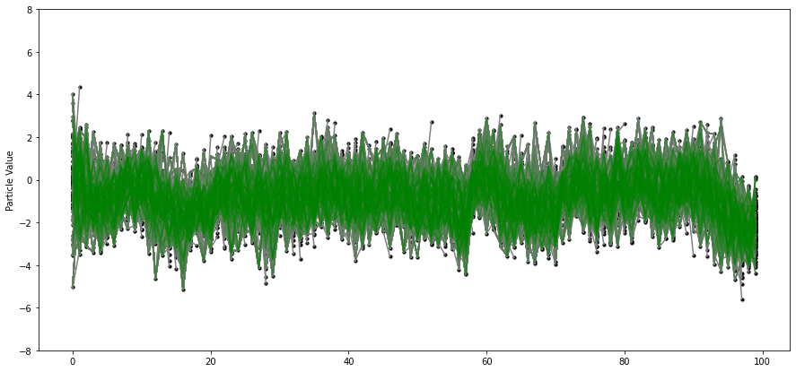

```python
warnings.filterwarnings(action='ignore')
plt.rc("figure", figsize=(15,7))
plt.ylim(-8,8)
plt.ylabel("Particle Value")
particleGeneologyAll(particles, ancs)
```

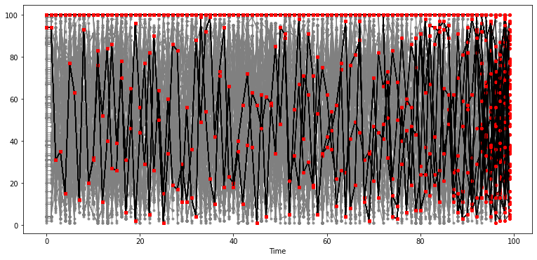

```python
warnings.filterwarnings(action='ignore')
plot_trajectories(particles, ancs, T=None)
```

## **2.2 Implement the Particle Gibbs with Ancestral Sampling (PGAS)**

In "[Particle Gibbs with ancestor sampling](https://www.jmlr.org/papers/volume15/lindsten14a/lindsten14a.pdf)" they point out that the resulting particle system in the PG sampler is undesirably biased towards the reference trajectory. This affects the path degeneracy in the way that most particles are resampled from the reference trajectory.

PGAS is a relatively small update of the PG sampler but comes with great benefits in terms of path degeneracy. Update your PG sampler above into the PGAS, repeat the following two exercises:

- **Report the approximate marginal likelihood**
- **Visualize the path degeneracy**

### The Particle Gibbs with Ancestral Sampling (PGAS) Implementation

```python
def cond_SMC_PGAS_kernel(data, x_ref, K, theta):
    """ *** BPF with multinomial resampling for PGAS ***
       data is an array of N observations
       K is the number of particles
       theta is a dictionary of parameters and their values"""

    beta_sq = theta[0]
    alpha = theta[1]
    sigma_sq = theta[2]
    y_n = data
    N = data.size

    a_n = {}
    xgen_n = {}
    w_n = {}

    a_n[0] = np.arange(K)
    xgen_n[0] = np.append(np.random.normal(loc=0, scale=np.sqrt(sigma_sq/(1-alpha**2)), size=(K-1)), x_ref[0])  #because q(x_1) = p(x_1)
    w_n[0] = np.repeat(1/K, K)

    for n in range(1,N):
        u = np.random.uniform(0, 1, size=(K-1))
        cum_w_prev_n = np.append(np.array([w_n[n-1][:k].sum() for k in range(1,K)]), 1)
        wK_n = norm.pdf(x_ref[n], loc=(alpha*xgen_n[n-1]), scale=np.sqrt(sigma_sq))
        a_n[n] = np.append(np.array([next(x[0] for x in enumerate(cum_w_prev_n) if x[1] > u[k]) for k in range(K-1)]), np.array(wK_n.argmax()))
        xgen_n[n] = np.append(np.random.normal(loc=(alpha*xgen_n[n-1][a_n[n][:-1]]), scale=np.sqrt(sigma_sq)), x_ref[n])
        w_n[n] = norm.pdf(y_n[n], loc=0, scale=np.sqrt((beta_sq)*np.exp(xgen_n[n])))
        if all(w_n[n] < 1e-4):
            w_n[n] += 1e-4
        w_n[n] /= w_n[n].sum()

    return(w_n, xgen_n, a_n)
```

```python
def run_PGAS_chain(nr_iter, data, theta_init, K, xref_init):

    alpha = theta_init[1]
    theta = {0: theta_init}
    x_ref = {0: xref_init}
    a_history = {}
    xgen_history = {}
    w_history = {}
    i = 0; j = 0; k = 0; l = 0
    for iter in range(1, nr_iter):
        w_n, xgen_n, a_n = cond_SMC_PGAS_kernel(data, x_ref[iter-1], K, theta[iter-1])
        xref = draw_from_SMC_mode(w_n, xgen_n, a_n, 1e-4)
        beta_sq, sigma_sq, flags = PG_kernel(data, xref, alpha, (.01, .01))

        x_ref[iter] = xref
        theta[iter] = [beta_sq, theta_init[1], sigma_sq]
        a_history[iter] = a_n
        xgen_history[iter] = xgen_n
        w_history[iter] = w_n
        i += flags[0]
        j += flags[1]
        k += flags[2]
        l += flags[3]

    print("Cases of diminutive beta_sq occurred in " + str(i) + " out of " + str(nr_iter) + " iterations")
    print("Cases of excessive beta_sq occurred in " + str(j) + " out of " + str(nr_iter) + " iterations")
    print("Cases of diminutive sigma_sq occurred in " + str(k) + " out of " + str(nr_iter) + " iterations")
    print("Cases of excessive sigma_sq occurred in " + str(l) + " out of " + str(nr_iter) + " iterations")

    return(x_ref, theta, a_history, xgen_history, w_history)
```

```python
np.random.seed(173710)

nr_iter = 25000
nr_chain = 4
K = 100  #nr. of particles to generate

theta0 = {0:[.4, .91, .4], 1:[.01, .91, 1], 2:[.7, .91, .7], 3:[1, .91, .01]}
x_ref0 = {}
for ch in range(nr_chain):
    x_ref0[ch] = generate_sv_latent_sequence(sv_obs, theta0[0])

all_xref2 = {}
all_theta2 = {}
all_ahistory2 = {}
all_xgenhistory2 = {}
all_whistory2 = {}

t0 = time.time()

for chain in range(nr_chain):
    x_ref, theta, a_history, xgen_history, w_history = run_PGAS_chain(nr_iter, sv_obs, theta0[chain], K, x_ref0[chain])

    all_xref2[chain] = x_ref
    all_theta2[chain] = theta
    all_ahistory2[chain] = a_history
    all_xgenhistory2[chain] = xgen_history
    all_whistory2[chain] = w_history

t1 = time.time()
total_time = t1 - t0
warnings.filterwarnings(action='once')
print('total time is', total_time//3600, 'hour', (total_time%3600)//60, 'minute', (total_time%3600)%60, 'seconds')
```

```
Cases of diminutive beta_sq occurred in 0 out of 25000 iterations
Cases of excessive beta_sq occurred in 0 out of 25000 iterations
Cases of diminutive sigma_sq occurred in 0 out of 25000 iterations
Cases of excessive sigma_sq occurred in 0 out of 25000 iterations
Cases of diminutive beta_sq occurred in 0 out of 25000 iterations
Cases of excessive beta_sq occurred in 0 out of 25000 iterations
Cases of diminutive sigma_sq occurred in 0 out of 25000 iterations
Cases of excessive sigma_sq occurred in 0 out of 25000 iterations
Cases of diminutive beta_sq occurred in 0 out of 25000 iterations
Cases of excessive beta_sq occurred in 0 out of 25000 iterations
Cases of diminutive sigma_sq occurred in 0 out of 25000 iterations
Cases of excessive sigma_sq occurred in 0 out of 25000 iterations
Cases of diminutive beta_sq occurred in 0 out of 25000 iterations
Cases of excessive beta_sq occurred in 0 out of 25000 iterations
Cases of diminutive sigma_sq occurred in 0 out of 25000 iterations
Cases of excessive sigma_sq occurred in 0 out of 25000 iterations
total time is 6.0 hour 19.0 minute 30.138928651809692 seconds
```

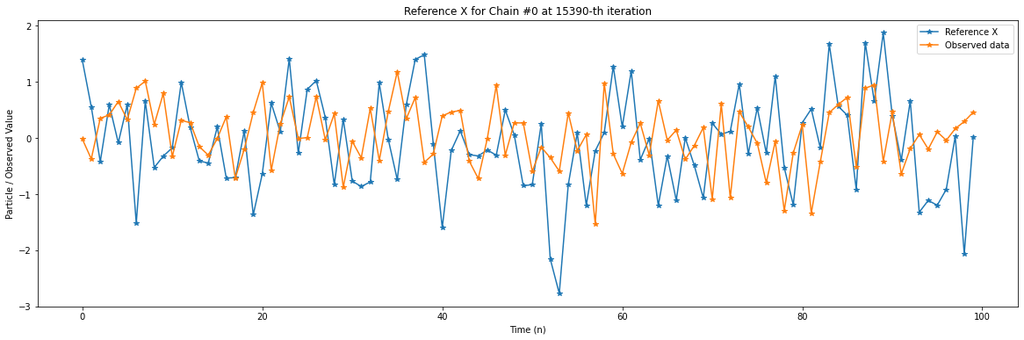

```python
i = 15390
chain = 0
plt.rc("figure", figsize=(20,6))
plt.plot(all_xref2[chain][i], '-*')
plt.plot(sv_obs, '-*')
plt.legend(["Reference X", "Observed data"])
plt.xlabel("Time (n)")
plt.ylabel("Particle / Observed Value")
plt.title("Reference X for Chain #" + str(chain) + " at " + str(i) + "-th iteration")
plt.show()
```

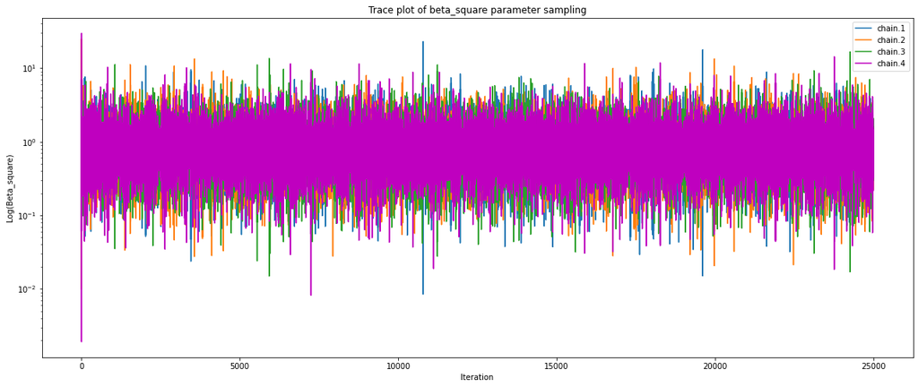

```python
# plot of chains: beta_sq
plt.rc("figure", figsize=(20,8))
plt.yscale("log")
plt.plot([all_theta2[0][iter][0] for iter in range(nr_iter)], '-')
plt.plot([all_theta2[1][iter][0] for iter in range(nr_iter)], '-')
plt.plot([all_theta2[2][iter][0] for iter in range(nr_iter)], '-')
plt.plot([all_theta2[3][iter][0] for iter in range(nr_iter)], '-m')
plt.legend(["chain.1","chain.2","chain.3","chain.4"])
plt.xlabel("Iteration")
plt.ylabel("Log(Beta_square)")
plt.title("Trace plot of beta_square parameter sampling")
plt.show()
```

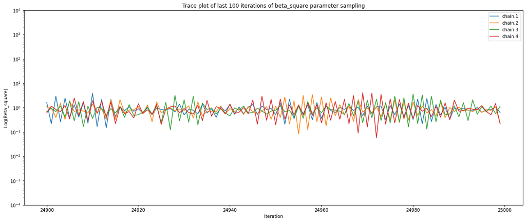

```python
# Convergence diagnostic: beta_sq, last i iterations
i = 100
plt.rc("figure", figsize=(20,8))
plt.yscale("log")
plt.plot(np.arange(nr_iter-i, nr_iter), [all_theta2[0][iter][0] for iter in range(nr_iter-i, nr_iter)], '-')
plt.plot(np.arange(nr_iter-i, nr_iter), [all_theta2[1][iter][0] for iter in range(nr_iter-i, nr_iter)], '-')
plt.plot(np.arange(nr_iter-i, nr_iter), [all_theta2[2][iter][0] for iter in range(nr_iter-i, nr_iter)], '-')
plt.plot(np.arange(nr_iter-i, nr_iter), [all_theta2[3][iter][0] for iter in range(nr_iter-i, nr_iter)], '-')
plt.legend(["chain.1","chain.2","chain.3","chain.4"])
plt.xlabel("Iteration")
plt.ylabel("Log(Beta_square)")
plt.ylim(10**-4, 10**4)
plt.title("Trace plot of last " + str(i) + " iterations of beta_square parameter sampling")
plt.show()
```

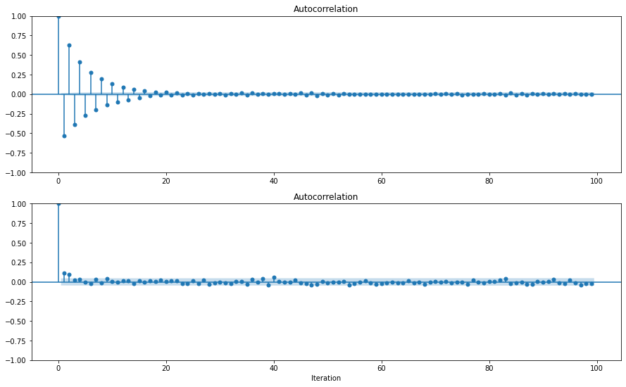

```python
# Diagnostic: ACF of beta_sq
which_chain = 0
burn_in = .25
thinning = .1

plt.rc("figure", figsize=(15,9))
fig, ax = plt.subplots(2)
plot_acf([all_theta2[which_chain][iter][0] for iter in range(nr_iter)], lags=99, ax=ax[0])
plot_acf([all_theta2[which_chain][iter][0] for iter in range(int(nr_iter*burn_in), nr_iter)][0::round(1/thinning)], lags=99, ax=ax[1])
ax[1].set_xlabel("Iteration")
plt.show()
```

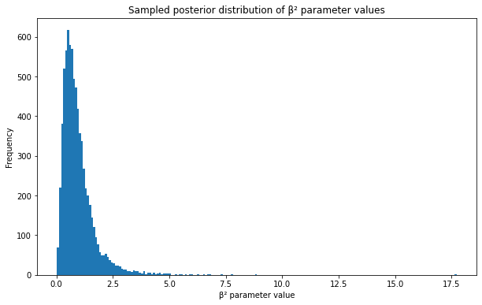

```
617.0
0.4716427874750904 0.5601247377689472
```

```python
# histogram of beta
burn_in = .25
thinning = .1
all_bsq2 = []
for c in range(nr_chain):
    all_bsq2.extend([all_theta2[c][iter][0] for iter in range(int(nr_iter*burn_in), nr_iter)])
sampled_bsq2 = np.array(all_bsq2[0::round(1/thinning)])
plt.rc("figure", figsize=(10,6))
n, bins, patches = plt.hist(sampled_bsq2[(sampled_bsq2 > 1e-4) & (sampled_bsq2 < 1000)], bins=200) #exclude too big values, for better display
plt.ylabel("Frequency")
plt.xlabel("\u03B2\N{SUPERSCRIPT TWO} parameter value")
plt.title("Sampled posterior distribution of \u03B2\N{SUPERSCRIPT TWO} parameter values")
plt.show()

print(n.max())
print(bins[n.argmax()], bins[n.argmax()+1])
```

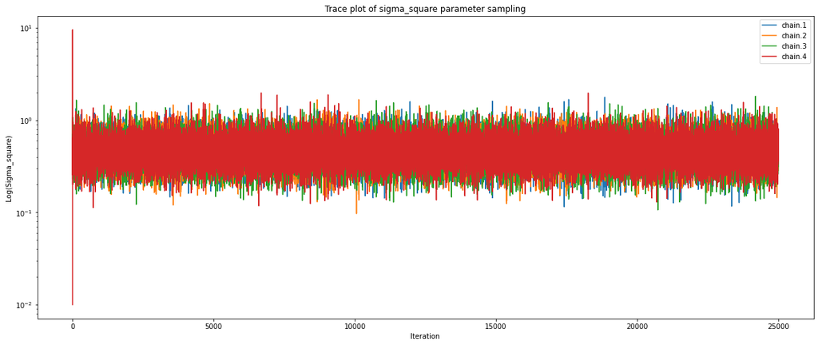

```python
# plot of chains: sigma_sq
plt.rc("figure", figsize=(20,8))
plt.yscale("log")
plt.plot([all_theta2[0][iter][2] for iter in range(nr_iter)], '-')
plt.plot([all_theta2[1][iter][2] for iter in range(nr_iter)], '-')
plt.plot([all_theta2[2][iter][2] for iter in range(nr_iter)], '-')
plt.plot([all_theta2[3][iter][2] for iter in range(nr_iter)], '-')
plt.legend(["chain.1","chain.2","chain.3","chain.4"])
plt.xlabel("Iteration")
plt.ylabel("Log(Sigma_square)")
plt.title("Trace plot of sigma_square parameter sampling")
plt.show()
```

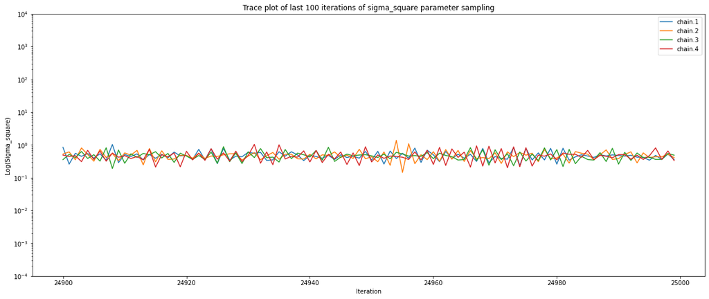

```python
# Convergence diagnostic: sigma_sq, last i iterations
i = 100
plt.rc("figure", figsize=(20,8))
plt.yscale("log")
plt.plot(np.arange(nr_iter-i, nr_iter), [all_theta2[0][iter][2] for iter in range(nr_iter-i, nr_iter)], '-')
plt.plot(np.arange(nr_iter-i, nr_iter), [all_theta2[1][iter][2] for iter in range(nr_iter-i, nr_iter)], '-')
plt.plot(np.arange(nr_iter-i, nr_iter), [all_theta2[2][iter][2] for iter in range(nr_iter-i, nr_iter)], '-')
plt.plot(np.arange(nr_iter-i, nr_iter), [all_theta2[3][iter][2] for iter in range(nr_iter-i, nr_iter)], '-')
plt.legend(["chain.1","chain.2","chain.3","chain.4"])
plt.xlabel("Iteration")
plt.ylabel("Log(Sigma_square)")
plt.ylim(10**-4, 10**4)
plt.title("Trace plot of last " + str(i) + " iterations of sigma_square parameter sampling")
plt.show()
```

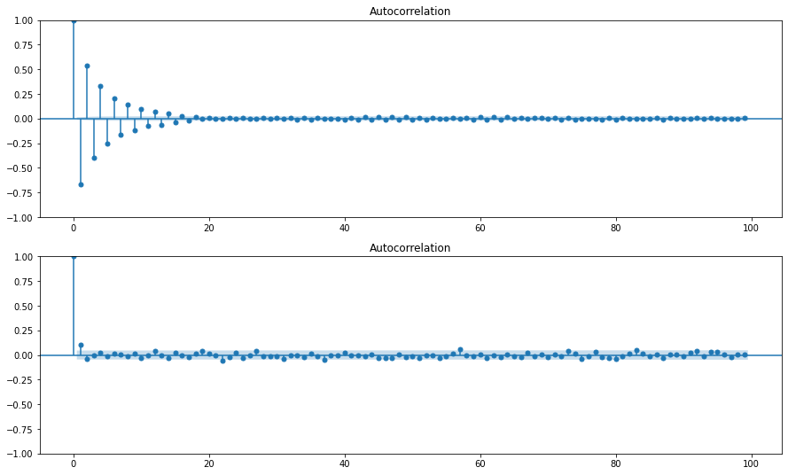

```python
# Diagnostic: ACF of sigma_sq
which_chain = 0
burn_in = .25
thinning = .1

plt.rc("figure", figsize=(15,9))
fig, ax = plt.subplots(2)
plot_acf([all_theta2[which_chain][iter][2] for iter in range(nr_iter)], lags=99, ax=ax[0])
plot_acf([all_theta2[which_chain][iter][2] for iter in range(int(nr_iter*burn_in), nr_iter)][0::round(1/thinning)], lags=99, ax=ax[1])
plt.show()
```

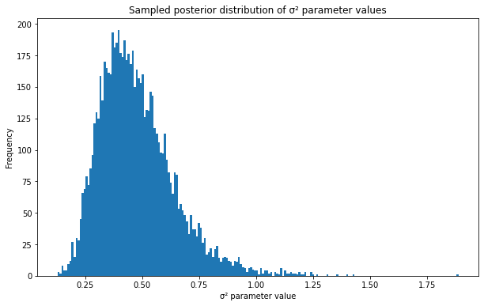

```
195.0
0.3919810465214235 0.400784465309342
```

```python
# histogram of sigma_sq
burn_in = .25
thinning = .1
all_ssq2 = []
for c in range(nr_chain):
    all_ssq2.extend([all_theta2[c][iter][2] for iter in range(int(nr_iter*burn_in), nr_iter)])
sampled_ssq2 = np.array(all_ssq2[0::round(1/thinning)])
plt.rc("figure", figsize=(10,6))
n, bins, patches = plt.hist(sampled_ssq2[(sampled_ssq2 > 1e-4) & (sampled_ssq2 < 1000)], bins=200) #exclude too big values, for better display
plt.ylabel("Frequency")
plt.xlabel("\u03C3\N{SUPERSCRIPT TWO} parameter value")
plt.title("Sampled posterior distribution of \u03C3\N{SUPERSCRIPT TWO} parameter values")
plt.show()

print(n.max())
print(bins[n.argmax()], bins[n.argmax()+1])
```

```python
# Marginal likelihood computation
sampled_theta2 = {'beta_sq':sampled_bsq2, 'sigma_sq':sampled_ssq2}
theta_sets2 = [(sampled_theta2['beta_sq'][s], .91, sampled_theta2['sigma_sq'][s]) for s in range(sampled_theta2['beta_sq'].size)]

t0 = time.time()

sum_lik_pair2 = 0
count_bad_exp2 = 0
for theta in theta_sets2:
    exponent = LL_BPF(sv_obs, theta, K, seed=173710)[-1]  #ll at the last time step N
    if np.isnan(np.array(exponent)):
        count_bad_exp2 += 1
        continue

    sum_lik_pair2 += np.exp(exponent)

marg_lik2 = sum_lik_pair2/(len(theta_sets2)-count_bad_exp2)

t1 = time.time()
total_time = t1 - t0
warnings.filterwarnings(action='once')
print('total time is', total_time//3600, 'hour', (total_time%3600)//60, 'minute', (total_time%3600)%60, 'seconds')
print('while catching ' + str(count_bad_exp2) + ' bad exponent(s)')
```

```
total time is 0.0 hour 15.0 minute 20.334830284118652 seconds
while catching 0 bad exponent(s)
```

```python
print('The a-posteriori marginal likelihood of the data over all sampled ' + str(len(theta_sets2)-count_bad_exp2) + ' parameter sets is ' + str(marg_lik2) + ' or equivalent to the a-posteriori log-likelihood of ' + str(np.log(marg_lik2)))
```

```
The a-posteriori marginal likelihood of the data over all sampled 7500 parameter sets is 3.067688714551839e-41 or equivalent to the a-posteriori log-likelihood of -93.28506439640897
```

```python
print('Thus, it is ' + str(round(np.exp(np.log(sum_lik_pair2) - np.log(sum_lik_pair)), 1)) + ' times more likely to observe the data with the PGAS-sampled parameter distributions compared to those obtained with PG')
```

```
Thus, it is 1.1 times more likely to observe the data with the PGAS-sampled parameter distributions compared to those obtained with PG
```

```python
which_chain = 0
which_iter = 15390
N = 100

ancs2, particles2, weights2 = get_an_iter_epoch(all_ahistory2[which_chain][which_iter], all_xgenhistory2[which_chain][which_iter], all_whistory2[which_chain][which_iter])
print(ancs2.shape)
print(particles2.shape)
print(weights2.shape)
```

```
(100, 100)
(100, 100)
(100, 100)
```

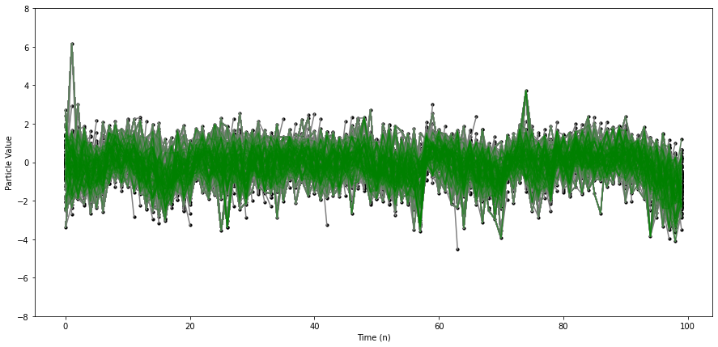

```python
warnings.filterwarnings(action='ignore')
plt.rc("figure", figsize=(15,7))
plt.ylim(-8,8)
plt.ylabel("Particle Value")
plt.xlabel("Time (n)")
particleGeneologyAll(particles2, ancs2)
```

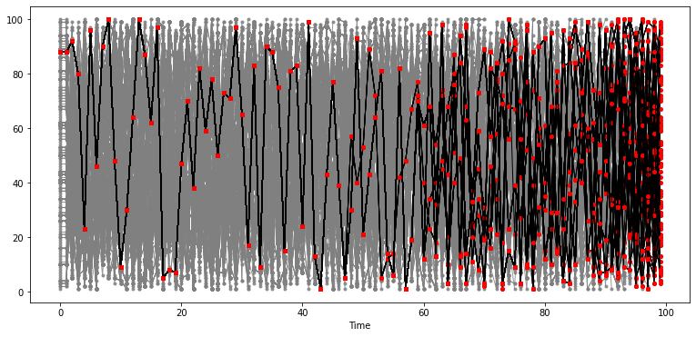

```python
warnings.filterwarnings(action='ignore')
plot_trajectories(particles2, ancs2, T=None)
```

#### Comment: The addition of ancestral sampling seemed to enable better exploration of the parameter space, which resulted in parameter distributions that are more likely to produce the observed data!

*Note: ...but at the expense of somewhat increased time complexity?*